# Plantilla descriptius

VHIR-UEB-for-019v.01

# 1 Introducció

Aquesta plantilla mostra un exemple d’anàlisi **descriptiva**, una anàlisi bàsica que pot servir de base d’anàlisis més complexes. És una tècnica que s’utilitza per a resumir i descriure de manera objectiva i neutral les dades a analitzar. Normalment, es realitza per a conèixer les característiques de la població d’estudi i es basa en taules de freqüències i en mesures estadístiques (mitjana, desviació, mediana, etc) i gràfics que descriuen la tendència central i la variabilitat.

Per a poder començar amb aquesta anàlisi en programari R, hem de seguir uns passos previs: identificar i instal·lar els paquets necessaris, importar la base de dades, explorar les dades i dur a terme tots els canvis pertinents en les variables i valors erronis. Després d’aquests passos, ja es pot procedir a l’anàlisi descriptiva.

En aquest exemple utilitzarem la base de dades **hta (Hipertensió arterial)**.

# 2 Instalació de paquets

Les versions noves dels paquets *knitr* i *kableExtra* donen problemes, per tant, per a poder instal·lar versions anteriors, desinstal·lem el paquet i a continuació utilitzem una de les dues funcions per a instal·lar paquets:

- `install_version()` del paquet *remotes*, que busca versions específiques del paquet demanat en repositoris de paquets i els instal·la. Per a poder utilitzar la funció cal especificar el nom del paquet (package) i la versió (version) a instal·lar i el repositori (repos), que en aquest cas és el repositori CRAN. Recomanat no actualitzar les dependències.

```r
> remove.packages("knitr") ## eliminem la versió que tinguem
> require(remotes)  ## cridem paquet
> remotes::install_version(package ="knitr", version ="1.43", repos=getOption("repos"))
```

- `install.packages()` del paquet *utils*, que descarrega o instal·la paquets de repositoris o d’arxius locals. Per a utilitzar la funció especifiquem que no busqui cap repositori (repos) i introduïm manualment la ruta de l’arxiu (pkgs) i el tipus de ruta (type).

```r
> remove.packages("kableExtra")
> require(utils)
> packageurl <- "https://cran.r-project.org/src/contrib/Archive/kableExtra/kableExtra_1.3.4.tar.gz"
> utils::install.packages(pkgs = packageurl, repos = NULL,type = "source")
```

Ara instal·lem i/o carreguem els altres paquets que necessitem. Els paquets creats per la UEB han estat baixats del github.

```r
> # install.packages("devtools")
> require(devtools)
>
> # install_github("miriammota/mmotaF")
> require(mmotaF)
>
> # install_github("uebvhir/anaStatsUEB")
> require(anaStatsUEB)
>
> # install.packages("pacman")
> require(pacman)
>
>
> pacman::p_load(rmdformats, rio, tidyr, stats, rstatix, rmarkdown, htmlTable,
+                grid, gridExtra, patchwork, ggpubr, gghalves, dplyr, magrittr,
+                forcats, nlme, skimr, sjPlot, plotmo, jtools, modelsummary,
+                gtsummary, ggstats, ggplot2)
```

# 3 Lectura i exploració de les dades

En el següent codi, s’utilitza la funció `import` del paquet *rio* per a carregar les dades que han estat descarregades del gitHub. Entre cometes s’especifica on es troben les dades guardades a l’ordinador, i si cal el tipus de format i la classe de l’arxiu.

```r
> name_file <- "hta.xls" # guardem el nom del archiu on estan les dades
> dat <- import(paste0("dades/", name_file),encoding = "UTF-8") # amb aquesta funció importem el data.frame de l'arxiu segons l'extensió de l'arxiu
```

Fem una petita exploració inicial de les 10 primeres files per donar-nos una idea de com és l’estructura de les dades.

```r
> (dat_orig <- dat) # guardem una copia de les dades originals
```

|  | numero | sexo | grupo | tas1 | tad1 | tas2 | tad2 | tas3 | tad3 | tas4 | tad4 | tas5 | tad5 | tas6 | tad6 | tas7 | tad7 | tas8 | tad8 | tas9 | tad9 | tas10 | tad10 | tas11 | tad11 | tas12 | tad12 |
| --- | --- | --- | --- | --- | --- | --- | --- | --- | --- | --- | --- | --- | --- | --- | --- | --- | --- | --- | --- | --- | --- | --- | --- | --- | --- | --- | --- |
| 1 | 1 | VARON | B | 150 | 100 | 150 | 90 | 170 | 90 | 175 | 85 | 140 | 90 | 140 | 80 | 140 | 85 | 150 | 90 | 145 | 85 | 150 | 95 | 150 | 90 | 150 | 80 |
| 2 | 2 | MUJER | B | 160 | 90 | 170 | 90 | 160 | 80 | 150 | 90 | 150 | 90 | 140 | 90 | 135 | 85 | 140 | 85 | 140 | 85 | 150 | 95 | 155 | 90 | 150 | 90 |
| 3 | 3 | MUJER | B | 150 | 90 | 110 | 90 | 115 | 90 | 120 | 80 | 125 | 85 | 130 | 85 | 120 | 80 | 130 | 75 | 120 | 80 | 130 | 90 | 130 | 95 | 110 | 85 |
| 4 | 4 | VARON | A | 120 | 80 | 140 | 90 | 140 | 90 | 130 | 90 | 130 | 95 | 130 | 100 | 150 | 90 | 130 | 90 | 150 | 95 | 135 | 80 | 140 | 90 | 130 | 90 |
| 5 | 5 | MUJER | A | 150 | 85 | 145 | 85 | 160 | 90 | 140 | 80 | 120 | 80 | 130 | 75 | 120 | 70 | 140 | 90 | 140 | 85 | 130 | 80 | 140 | 80 | 120 | 80 |
| 6 | 6 | MUJER | B | 140 | 75 | 160 | 70 | 135 | 75 | 140 | 70 | 140 | 75 | 140 | 80 | 150 | 75 | 160 | 80 | 160 | 80 | 130 | 70 | 140 | 75 | 140 | 90 |
| 7 | 7 | MUJER | A | 150 | 100 | 140 | 90 | 130 | 95 | 130 | 85 | 135 | 95 | 145 | 90 | 130 | 90 | 130 | 90 | 140 | 90 | 140 | 80 | 130 | 85 | 135 | 75 |
| 8 | 8 | VARON | A | 160 | 90 | 170 | 90 | 170 | 80 | 160 | 80 | 160 | 90 | 160 | 85 | 170 | 75 | 150 | 80 | 160 | 80 | 155 | 80 | 160 | 70 | 150 | 90 |
| 9 | 9 | MUJER | A | 145 | 105 | 170 | 95 | 140 | 85 | 135 | 85 | 135 | 85 | 145 | 90 | 135 | 80 | 140 | 90 | 130 | 80 | 140 | 85 | 125 | 75 | 140 | 85 |
| 10 | 10 | MUJER | A | 210 | 110 | NA | NA | NA | NA | NA | NA | NA | NA | NA | NA | NA | NA | NA | NA | NA | NA | NA | NA | NA | NA | NA | NA |

[output cut: 50 more lines]

Un *data frame* pot contenir diferents tipus de dades: numèriques (1, 2, 3 o 12.4, 15.0), caràcter (“Hola”, “Id104”), factor (Si, No o A, B, C) i lògiques (TRUE/FALSE).

Les variables que tenim al *data frame* són les següents:

- `numero`: variable numèrica que correspon a l’identificador del pacient
- `sexo`: variable caràcter que indica el sexe amb valors VARON i MUJER
- `grupo`: variable caràcter que indica el grup de seguiment amb valors A i B
- `tas1 a tas12`: variables numèriques que corresponen a valors de pressió sistòlica en 12 temps diferents
- `tad1 a tad12`: variables numèriques que corresponen a valors de pressió diastòlica en 12 temps diferents

**Canvis que hem de fer en les variables:** canviar els noms perquè segueixin els estàndards, assignar a l’identificador de registre el nom “id” i convertir-lo a tipus caràcter, convertir a tipus factor *sexo* i *grupo*, i eliminar aquelles variables que no s’utilitzaran.

La funció `clean_names()` del paquet *janitor* s’utilitza per a netejar els noms de les columnes, és a dir, canvia les majúscules a minúscules, elimina els accents, substitueix els espais per guions baixos i més.

La funció `rename()` del paquet *dplyr* canvia els noms de les variables individualment (new_name = “old_name”).

La funció `mutate_at()` del paquet *dplyr* transforma múltiples variables seleccionades a partir d’un vector amb el nom d’aquestes variables. Si volem transformar totes les variables d’un *data frame* podem utilitzar `mutate_all()` o si volem transformar un conjunt de variables amb una condició utilitzarem `mutate_if()`. Una transformació seria passar de variable factor a caràcter amb `as.character()` o viceversa amb `as.factor()` del paquet *base*.

La funció `NAperc()$var` del paquet *mmotaF* dona el nom d’aquelles variables amb més de X percentatge de valors faltants.

```r
> ## Canviem els noms de les variables per a que segueixin els estandars
> dat <- janitor::clean_names(dat)
>
> ## Assignem al identificador de registre el nom 'id'
> dat<- dat %>% rename(id = "numero")
>
> ## variables CARACTER
> var_char <- names(dat %>% select(id))
> dat <- dat %>% mutate_at(var_char,as.character)
>
> ## variables FACTOR
> var_fact <- names(dat %>% select(sexo, grupo))
> dat <- dat %>% mutate_at(var_fact,as.factor)
>
> ## seleccionem variables amb un 95% de valors faltants
> var_del <- NAperc(dat, maxNA = 95)$var
> dat <- dat %>% select(-var_del)
```

Tornem a fer l’exploració de les dades una vegada fets els canvis per comprovar que tot estigui correcte, però ara amb la funció `str()` del paquet *utils*, que mostra de manera comprimida l’estructura interna del *data frame* (noms i tipus de variables amb els respectius nivells en el cas de les variables tipus factor).

```r
> str(dat)
```

```
## 'data.frame':    60 obs. of  27 variables:
##  $ id   : chr  "1" "2" "3" "4" ...
##  $ sexo : Factor w/ 2 levels "MUJER","VARON": 2 1 1 2 1 1 1 2 1 1 ...
##  $ grupo: Factor w/ 2 levels "A","B": 2 2 2 1 1 2 1 1 1 1 ...
##  $ tas1 : num  150 160 150 120 150 140 150 160 145 210 ...
##  $ tad1 : num  100 90 90 80 85 75 100 90 105 110 ...
##  $ tas2 : num  150 170 110 140 145 160 140 170 170 NA ...
##  $ tad2 : num  90 90 90 90 85 70 90 90 95 NA ...
##  $ tas3 : num  170 160 115 140 160 135 130 170 140 NA ...
##  $ tad3 : num  90 80 90 90 90 75 95 80 85 NA ...
##  $ tas4 : num  175 150 120 130 140 140 130 160 135 NA ...
##  $ tad4 : num  85 90 80 90 80 70 85 80 85 NA ...
##  $ tas5 : num  140 150 125 130 120 140 135 160 135 NA ...
##  $ tad5 : num  90 90 85 95 80 75 95 90 85 NA ...
##  $ tas6 : num  140 140 130 130 130 140 145 160 145 NA ...
##  $ tad6 : num  80 90 85 100 75 80 90 85 90 NA ...
##  $ tas7 : num  140 135 120 150 120 150 130 170 135 NA ...
##  $ tad7 : num  85 85 80 90 70 75 90 75 80 NA ...
##  $ tas8 : num  150 140 130 130 140 160 130 150 140 NA ...
##  $ tad8 : num  90 85 75 90 90 80 90 80 90 NA ...
##  $ tas9 : num  145 140 120 150 140 160 140 160 130 NA ...
##  $ tad9 : num  85 85 80 95 85 80 90 80 80 NA ...
##  $ tas10: num  150 150 130 135 130 130 140 155 140 NA ...
##  $ tad10: num  95 95 90 80 80 70 80 80 85 NA ...
##  $ tas11: num  150 155 130 140 140 140 130 160 125 NA ...
##  $ tad11: num  90 90 95 90 80 75 85 70 75 NA ...
##  $ tas12: num  150 150 110 130 120 140 135 150 140 NA ...
##  $ tad12: num  80 90 85 90 80 90 75 90 85 NA ...
```

Identifiquem i agrupem les variables:

```r
> var_tas <- grep("tas", names(dat), value = T) # variables que contenen "tas" al nom
> var_tad <- grep("tad", names(dat), value = T) # variables que contenen "tad" al nom
> var_names <- names(dat) # nom de totes les variables
> var_group <- c("sexo", "grupo") # variables grupo
> var_select <- c("sexo", "grupo","tas1","tad1") # variables seleccionadas
> var_long <- c("tas","tad") # Variables longitudinales a analizar
> var_id <- "id" # Identificador del subjecte
> var_event = "Tiempo" # Temps de seguiment ( factor)
```

Si tenim diferents mesures per a una mateixa variable (mesures repetides), com és el cas de les variables *tas* i *tad*, és necessari transformar aquestes variables de format ample a llarg, o sigui passar de x columnes amb valors, a 1 columna amb el nom de les x columnes anteriors com a etiquetes i 1 columna amb els valors. S’ha de tenir en compte que si tenim més d’una variable a transformar, cal realitzar els següents passos per a cadascuna d’elles:

- Convertir tota la base de dades a format llarg amb la funció `gather()` del paquet *tidyr* indicant quines són les columnes amb els valors a transformar i el nom de les columnes on aniran les etiquetes i els valors, obtenint una nova base de dades.
- Si la nova columna amb etiquetes, té una part comuna que volem eliminar, com per exemple: es repeteix el nom de la variable a transformar o hi ha un tipus de patró, ho podem fer amb la funció `str_remove()` del paquet *stringr*, on només cal indicar la columna (string) i el que volem eliminar (pattern).

Finalment, fusionem les noves bases de dades obtingudes de *tas* i *tad* en un altre *data frame* utilitzant la funció `merge()` del paquet *data.table* i verifiquem que cada variable estigui en el format adequat. Per facilitar i accelerar la unió, és important que les columnes amb noms idèntics en ambdues bases de dades continguin les mateixes dades; en cas contrari, seran introduïdes amb noms diferents i caldrà revisar-les i eliminar-les més endavant.

(Només agafem els pacients que tenen totes les dades)

```r
> # Convertim els valors de "tas" a format llarg
> dat_tas <- gather(dat[complete.cases(dat),],key = "Tiempo", value = "tas",var_tas)
>
> # seleccionem les columnes necessaries
> dat_tas <- select(dat_tas,c("id", "sexo", "grupo", "Tiempo", "tas"))
>
> # eliminem la part comuna de les etiquetes
> dat_tas$Tiempo <- str_remove(dat_tas$Tiempo,"tas")
>
> # Repetim els pasos anteriors amb els valors de "tad"
> dat_tad <- gather(dat[complete.cases(dat),],key = "Tiempo", value = "tad",var_tad)
> dat_tad <- select(dat_tad,c("id", "sexo", "grupo", "Tiempo", "tad"))
> dat_tad$Tiempo <- str_remove(dat_tad$Tiempo,"tad")
>
> # Unim les bases de dades
> dat_long <- merge(dat_tas,dat_tad)
>
> # Convertim la variables amb els temps de seguiment a factor
> dat_long$Tiempo <- as.factor(dat_long$Tiempo)
>
> # Reordenem els nivells en el cas que no siguin els correctes
> dat_long <-  reorder_levels(dat_long, Tiempo, c("1","2","3","4","5","6","7","8","9","10","11","12"))
>
> # Comprovem que l'ordre es correcte
> table(dat_long$Tiempo)
```

```
##
##  1  2  3  4  5  6  7  8  9 10 11 12
## 49 49 49 49 49 49 49 49 49 49 49 49
```

Tornem a fer l’exploració de les dades però ara amb format llarg:

```r
> str(dat_long)
```

```
## 'data.frame':    588 obs. of  6 variables:
##  $ id    : chr  "1" "1" "1" "1" ...
##  $ sexo  : Factor w/ 2 levels "MUJER","VARON": 2 2 2 2 2 2 2 2 2 2 ...
##  $ grupo : Factor w/ 2 levels "A","B": 2 2 2 2 2 2 2 2 2 2 ...
##  $ Tiempo: Factor w/ 12 levels "1","2","3","4",..: 1 10 11 12 2 3 4 5 6 7 ...
##  $ tas   : num  150 150 150 150 150 170 175 140 140 140 ...
##  $ tad   : num  100 95 90 80 90 90 85 90 80 85 ...
```

Tots els anàlisis han estat realitzats amb el programa estadístic “R”( R version 4.4.0 (2024-04-24 ucrt), Copyright (C) 2015 The R Foundation for Statistical Computing ).

# 4 Anàlisi descriptiva

Una primera anàlisi descriptiva ens mostra un resum general de les dades. Aquesta anàlisi ens permet realitzar una exploració inicial de les dades i detectar possibles errors en l’entrada de dades. La funció `desc_group()` del paquet *anaStatsUEB* ens retorna una taula descriptiva llesta per a ser visualitzada en html, depenent del tipus de covariable la funció calcula diferents estadístics:

- Per a les variables **categòriques** calcula les freqüències absolutes, les relatives en percentatge i l’interval de confiança exacte al 95%.

La fórmula de l’interval de confiança per a una proporció: $IC = p_x \pm z_{1-\alpha/2} \sqrt{\frac{p_x(1-p_x)}{n}}$

On:

– $p = \frac{X}{n}$ és la proporció mostral o freqüència relativa,

– $X$ és la freqüència de cada categoria o absoluta

– $z$ és la puntuació z corresponent al nivell de confiança del $Q%$ on $Q=1-\alpha$, que per a $\alpha = 0.05$ és aproximadament 1.96, aquest valor només ho podem utilitzar si la variància poblacional és coneguda.

– $n$ és la mida de la mostra.

- Per a les variables **contínues** calcula la mitjana i la desviació típica -mean(sd)- amb l’interval de confiança per a la mitjana al 95% -IC[,]- i la mediana i el primer i tercer quartil -median[Q1,Q3]-.
  - **Mitjana:** suma de tots els valors dividida entre el nombre de valors, és a dir, promig de tots els valors.

  La fórmula per calcular la mitjana: $\bar{X} = \frac{\sum_{i=1}^{n}{x_i}}{n}$

  On:

  – $x_i$ és cada valor individual en el conjunt de dades
  - **Desviació típica:** mesura que indica quant es desvien els valors individuals del promig.

  La fórmula per calcular la desviació típica és la següent: $S =\sqrt{\frac{1}{n-1}\sum_{i=1}^{n} (x_i - \bar{X})^2}$
  - **Interval de confiança:** proporciona un marge d’error dins del qual es troba la mitjana.

  La fórmula per l’interval de confiança per a la mitjana al 95%: $IC = \bar{X} \pm t_{n-1,1-\alpha/2} \cdot \frac{S_x}{\sqrt{n}}$

  On:

  – $t_{n-1,(1+0.95)/2}$ indica el 0.975-quantil de la distribució $t_{n-1}$ (t d’Student)
  - **Mediana:** valor que es troba al centre ordenant les dades de manera ascendent.
  - **Quartils:** valors que divideixen les dades en quatre parts iguals, per tant, el Q1 i Q3 representen respectivament el 25% i 75% de les dades.

  La formula per calcular la posició d’un quartil: $Q_k = \frac{k \cdot (n+1)}{4}, \space per \space a \space k =1,3$

```r
> res <- desc_group(covariates = var_select, data = dat)
> res$res
```

Table 4.1: Summary statistics table

| variable | levels | ALL | n |
| --- | --- | --- | --- |
| sexo<sub>1</sub> | MUJER | 37 (61.7%) [48.2; 73.9] | 60 |
|  | VARON | 23 (38.3%) [26.1; 51.8] |  |
| grupo<sub>1</sub> | A | 29 (48.3%) [35.2; 61.6] | 60 |
|  | B | 31 (51.7%) [38.4; 64.8] |  |
| tas1<sub>2</sub> |  | 60 150.1 (19.3) CI[145.1;155.1] 145 [140,160] | 60 |
| tad1<sub>2</sub> |  | 60 88.4 (10.1) CI[85.8;91] 90 [80,95] | 60 |

* 1: n(%) [Exact CI]  
† 2: N mean(sd) [CI95% mean] median[IQR]

```r
> res_g <- desc_group(covariates = "sexo", group = "grupo", data = dat,show.all = F, show.pval = F)
> res_g$res
```

Table 4.1: Summary of results by groups of grupo

| variable | levels | A 29 (48.33%) | B 31 (51.67%) | n |
| --- | --- | --- | --- | --- |
| sexo<sub>1</sub> | MUJER | 17 (58.6%) CI[38.9; 76.5] | 20 (64.5%) CI[45.4; 80.8] | 60 |
|  | VARON | 12 (41.4%) CI[23.5; 61.1] | 11 (35.5%) CI[19.2; 54.6] |  |

* 1: by col n(%) [Exact CI]  
†

```r
> res_l <- desc_group(covariates = var_long,group = var_event, data = dat_long,
+                    show.pval = FALSE,show.n = F,show.all = F)
> res_l$res
```

Table 4.1: Summary of results by groups of Tiempo

| variable | levels | 1 49 (8.33%) | 2 49 (8.33%) | 3 49 (8.33%) | 4 49 (8.33%) | 5 49 (8.33%) | 6 49 (8.33%) | 7 49 (8.33%) | 8 49 (8.33%) | 9 49 (8.33%) | 10 49 (8.33%) | 11 49 (8.33%) | 12 49 (8.33%) |
| --- | --- | --- | --- | --- | --- | --- | --- | --- | --- | --- | --- | --- | --- |
| tas<sub>2</sub> |  | 49 149.4 (17.4) CI[144.4; 154.4] 145 [140, 160] | 49 145.6 (15.6) CI[141.1; 150.1] 140 [135, 160] | 49 142.4 (16.6) CI[137.7; 147.2] 140 [130, 150] | 49 138.6 (14.9) CI[134.3; 142.8] 140 [130, 150] | 49 138.6 (14.5) CI[134.4; 142.7] 140 [130, 145] | 49 133.7 (13.1) CI[129.9; 137.4] 130 [125, 140] | 49 134.9 (15) CI[130.6; 139.2] 130 [125, 140] | 49 137.4 (10.1) CI[134.5; 140.4] 140 [130, 145] | 49 137.4 (12.3) CI[133.9; 141] 140 [130, 140] | 49 140 (17.3) CI[135; 145] 140 [130, 150] | 49 140.6 (15.2) CI[136.3; 145] 140 [130, 150] | 49 136.6 (13.8) CI[132.6; 140.5] 140 [130, 150] |
| tad<sub>2</sub> |  | 49 87.3 (9.7) CI[84.5; 90.1] 90 [80, 95] | 49 86.3 (9.3) CI[83.6; 89] 90 [80, 90] | 49 86 (9) CI[83.4; 88.6] 85 [80, 90] | 49 85.3 (7.8) CI[83.1; 87.5] 85 [80, 90] | 49 85.6 (8.5) CI[83.2; 88.1] 85 [80, 90] | 49 83.4 (6.6) CI[81.5; 85.3] 85 [80, 90] | 49 83.5 (9.1) CI[80.8; 86.1] 85 [80, 90] | 49 84.4 (7.2) CI[82.3; 86.5] 85 [80, 90] | 49 85.3 (8.4) CI[82.9; 87.7] 85 [80, 90] | 49 85.4 (8.6) CI[82.9; 87.9] 85 [80, 90] | 49 84.5 (7.8) CI[82.3; 86.7] 85 [80, 90] | 49 85 (7.7) CI[82.8; 87.2] 85 [80, 90] |

† 2: N mean(sd) [CI95% mean] median[IQR]

Una anàlisi gràfica ens dona una millor interpretació de les dades. La funció `desc_plot()` de paquet *mmotaF* genera a partir d’un *data frame* gràfics univariants per a cadascuna de les variables que s’indiquen, depenent del tipus de covariable la funció realitza diferents tipus de gràfics, a excepció de si les variables son de tipus caracter que no en fa cap.

- Per a les variables **categòriques** realitza un diagrama de barres, on cada barra indica una categoria i l’eix vertical el percentatge, el recompte absolut es mostra en cadascuna de les categories. En el cas de tenir una variable grup, cada barra arriba fins al 100% i es divideix segons les categories de la variable grup.
- Per a les variables **numèriques** realitza un histograma o un diagrama de caixes en el cas que tinguem una variable grup.

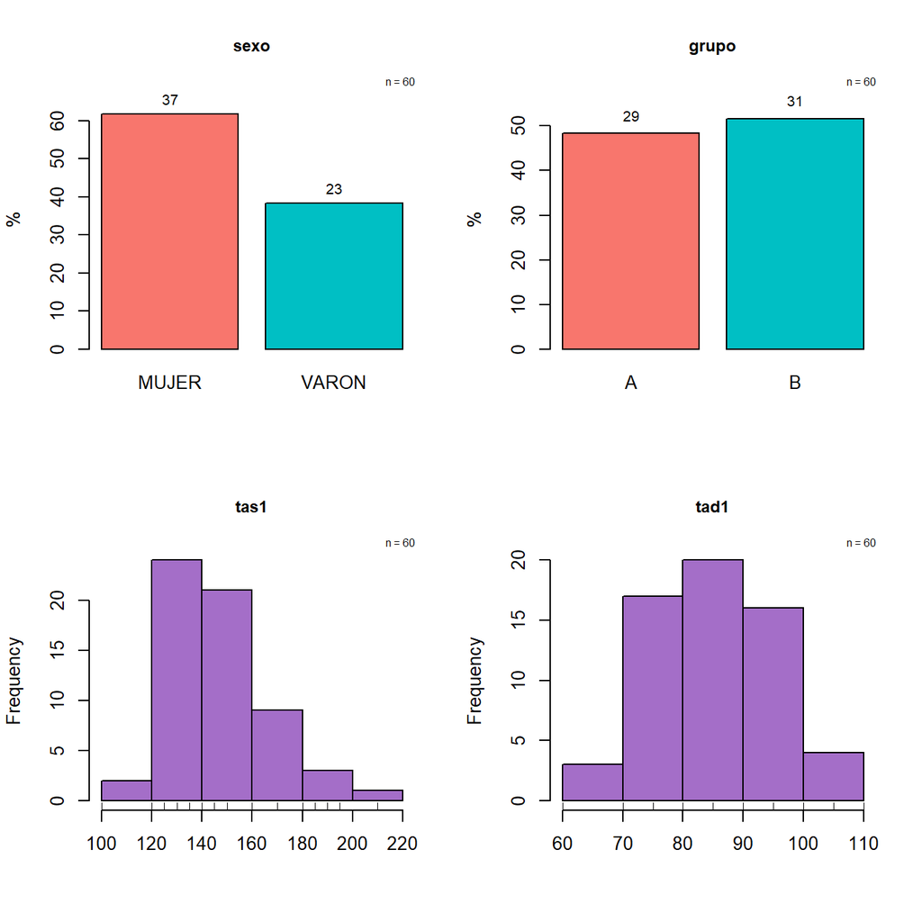

```r
> desc_plot(dat = dat, covariates = var_select,rowcol = c(2,2))
```

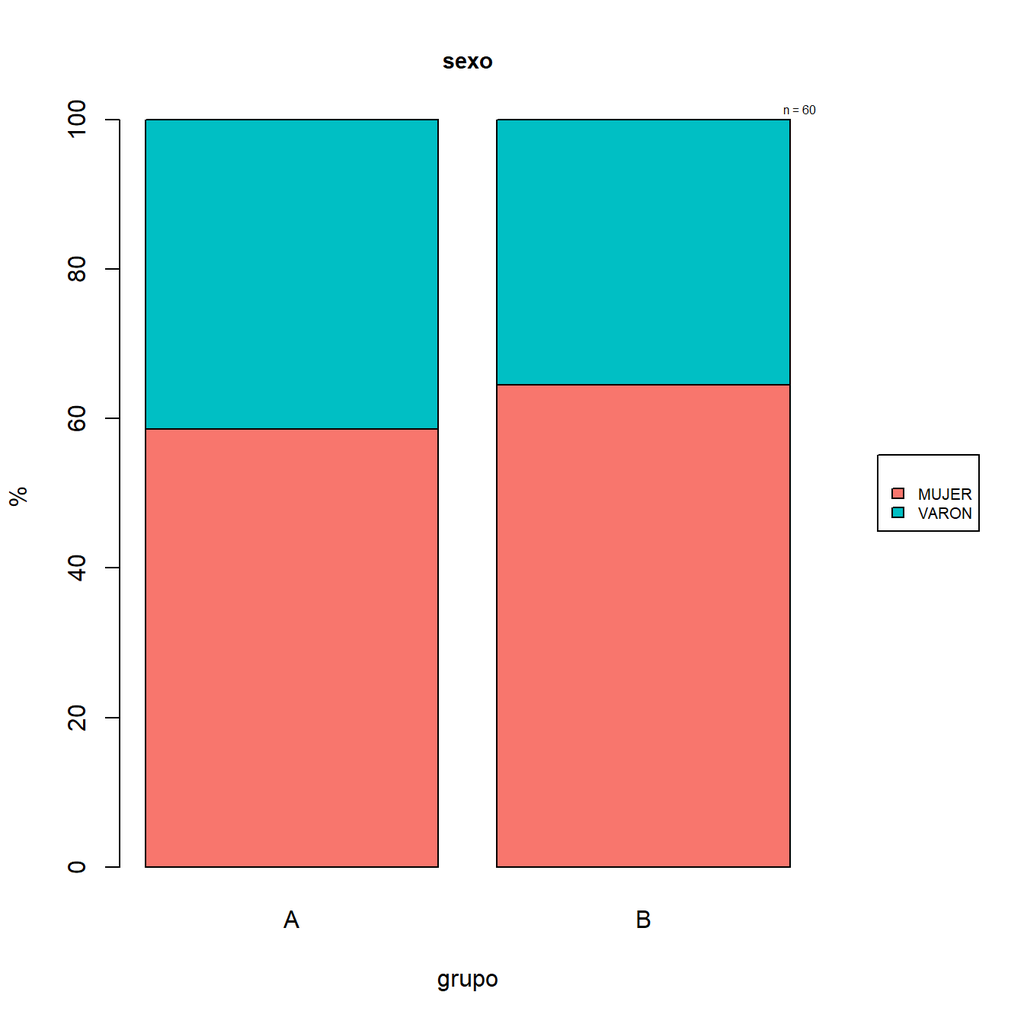

```r
> desc_plot(covariates = "sexo", y = "grupo", dat = dat, rowcol = c(1,1))
```

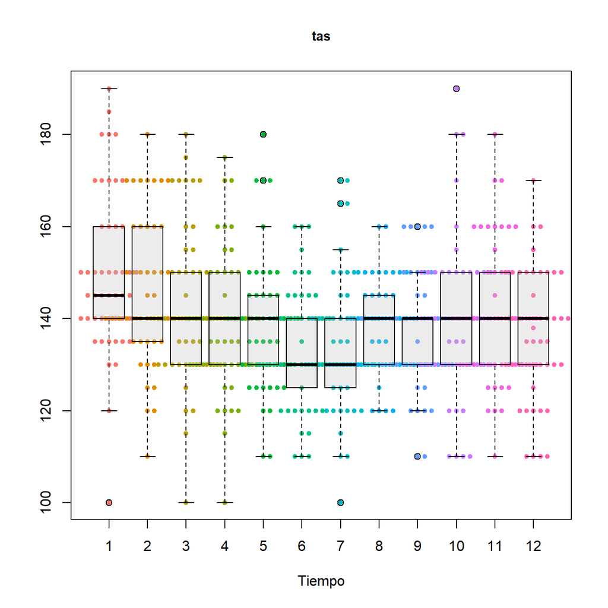

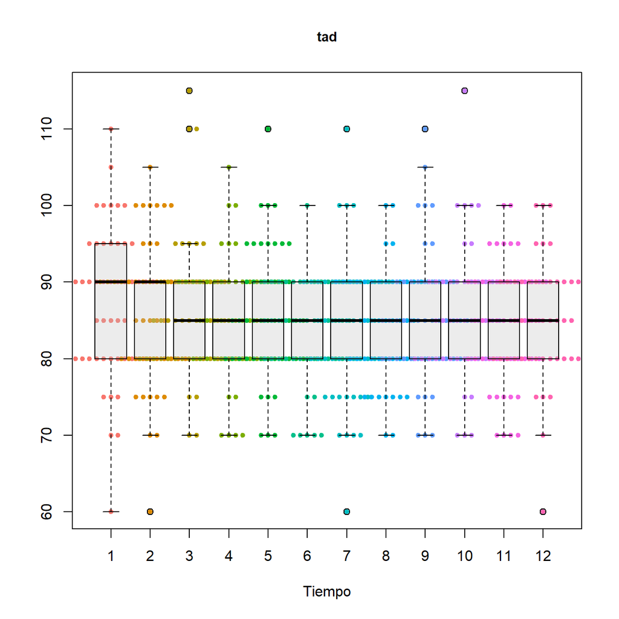

```r
> desc_plot(covariates  = var_long ,y = var_event,dat = dat_long,show.n = F, rowcol = c(1,1))
```

En aquest exemple veiem que hi ha més MUJER que VARON, hi ha dues persones més en el grup B respecte el A, la mitjana de tas1 és de 150.1 amb una desviació de 19.3, i la mitjana de tad1 és de 88.4 amb una desviació de 10.1.